# Depression Patient Outcome Study

Lingge Li

11/21/2016

## Patient outcome

```r
load('Depression.RData')
Depression <- Depression[Depression$GROUP_ID==2,]
summary(Depression$Pre_BDI)
```

```
##    Min. 1st Qu.  Median    Mean 3rd Qu.    Max.
##      20      24      30      31      36      60
```

```r
summary(Depression$POST_BDI)
```

```
##    Min. 1st Qu.  Median    Mean 3rd Qu.    Max.
##     0.0     6.0    14.0    15.9    22.0    60.0
```

Changes in BDI are mostly positive.

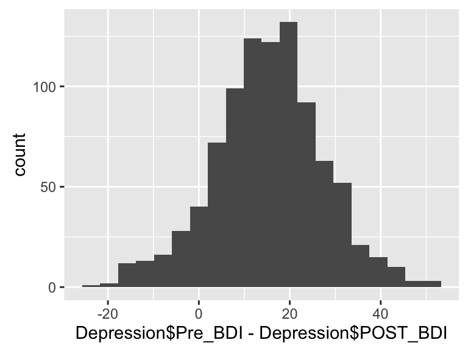

```r
library(ggplot2)
qplot(Depression$Pre_BDI-Depression$POST_BDI, bins=20)
```

In the original data, all patients who have low BDI to start with are considered non-responders, which is inconsistent with our discussion.

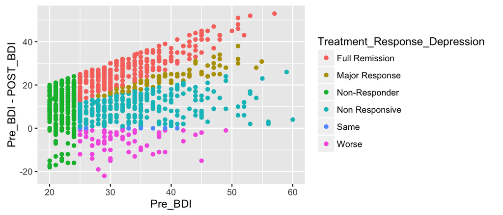

```r
ggplot(data=Depression,aes(x=Pre_BDI,y=Pre_BDI-POST_BDI,colour=Treatment_Response_Depression)) + geom_point()
```

We consider patients who improve BDI by more than 50% as responders.

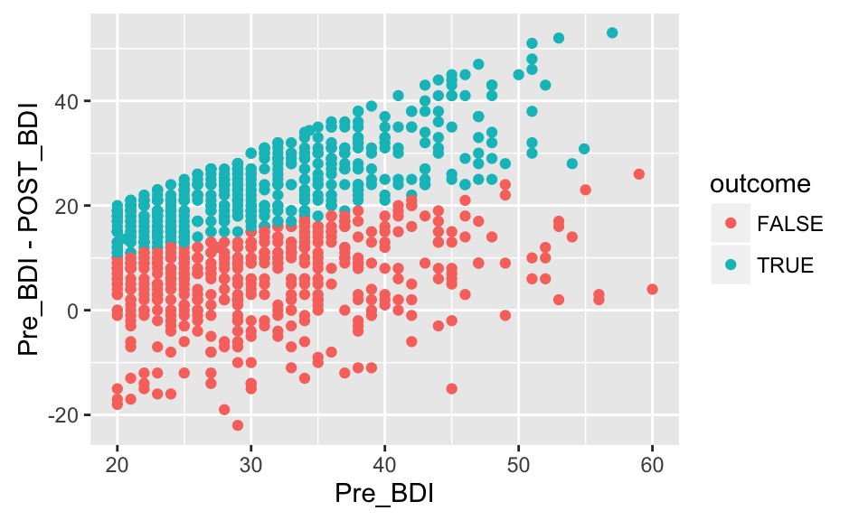

```r
outcome <- (Depression$Pre_BDI-Depression$POST_BDI)>0.5*Depression$Pre_BDI
temp <- data.frame(Pre_BDI=Depression$Pre_BDI,POST_BDI=Depression$POST_BDI,outcome)
ggplot(data=temp,aes(x=Pre_BDI,y=Pre_BDI-POST_BDI,colour=outcome)) + geom_point()
```

## Brain regions

Here we first look at brain region scores of baseline SPECT scan.

```r
summary(Depression[,125:252])
```

```
##  T_Baseline_Amygdala_L T_Baseline_Amygdala_R T_Baseline_Angular_L
##  Min.   :32.80         Min.   :33.72         Min.   :26.14
##  1st Qu.:48.57         1st Qu.:48.18         1st Qu.:44.54
##  Median :52.86         Median :52.70         Median :47.98
##  Mean   :53.41         Mean   :53.16         Mean   :48.12
##  3rd Qu.:57.84         3rd Qu.:57.96         3rd Qu.:51.53
##  Max.   :87.00         Max.   :92.43         Max.   :71.81
##  NA's   :92            NA's   :92            NA's   :92
##  T_Baseline_Angular_R T_Baseline_Calcarine_L T_Baseline_Calcarine_R
##  Min.   :26.85        Min.   :33.94          Min.   :36.03
##  1st Qu.:40.45        1st Qu.:49.52          1st Qu.:51.72
##  Median :43.23        Median :53.18          Median :55.67
##  Mean   :43.40        Mean   :53.32          Mean   :55.80
##  3rd Qu.:46.22        3rd Qu.:56.95          3rd Qu.:59.78
##  Max.   :60.83        Max.   :80.33          Max.   :93.52
##  NA's   :92           NA's   :92             NA's   :92
##  T_Baseline_Caudate_L T_Baseline_Caudate_R T_Baseline_Cerebellum_10_L
##  Min.   :29.42        Min.   :28.46        Min.   :17.20
##  1st Qu.:46.46        1st Qu.:48.71        1st Qu.:35.63
##  Median :50.85        Median :53.03        Median :39.88
##  Mean   :51.26        Mean   :53.43        Mean   :40.31
##  3rd Qu.:56.09        3rd Qu.:57.99        3rd Qu.:44.42
##  Max.   :82.87        Max.   :85.76        Max.   :68.07
##  NA's   :86           NA's   :86           NA's   :93
##  T_Baseline_Cerebellum_10_R T_Baseline_Cerebellum_3_L
##  Min.   :11.38              Min.   :34.40
##  1st Qu.:32.32              1st Qu.:50.14
##  Median :36.55              Median :54.38
##  Mean   :36.81              Mean   :54.78
##  3rd Qu.:40.65              3rd Qu.:59.06
##  Max.   :64.10              Max.   :87.07
##  NA's   :93                 NA's   :94
##  T_Baseline_Cerebellum_3_R T_Baseline_Cerebellum_4_5_L
##  Min.   :32.05             Min.   :34.20
##  1st Qu.:48.73             1st Qu.:52.63
##  Median :52.69             Median :57.30
##  Mean   :52.99             Mean   :57.38
##  3rd Qu.:57.35             3rd Qu.:62.01
##  Max.   :80.26             Max.   :92.17
##  NA's   :92                NA's   :92
```

[output cut: 401 more lines]

```
##  Min.   : 25.05      Min.   :21.32       Min.   :23.63
##  1st Qu.: 57.90      1st Qu.:52.66       1st Qu.:51.85
##  Median : 63.04      Median :58.25       Median :57.68
##  Mean   : 63.32      Mean   :58.09       Mean   :57.34
##  3rd Qu.: 68.72      3rd Qu.:64.09       3rd Qu.:62.53
##  Max.   :102.26      Max.   :92.16       Max.   :87.60
##  NA's   :92          NA's   :92          NA's   :92
##  T_Baseline_Vermis_9
##  Min.   : 30.07
##  1st Qu.: 59.61
##  Median : 65.00
##  Mean   : 65.43
##  3rd Qu.: 70.94
##  Max.   :111.69
##  NA's   :92
```

```r
NAs <- apply(Depression[,125:252], 1, function(x) sum(is.na(x)))
summary(NAs)
```

```
##    Min. 1st Qu.  Median    Mean 3rd Qu.    Max.
##     0.0     0.0     0.0    12.8     0.0   128.0
```

```r
Depression <- Depression[NAs<100,]
Depression[,'T_Baseline_Cerebellum_10_L'][is.na(Depression[,'T_Baseline_Cerebellum_10_L'])] <- mean(Depression[,'T_Baseline_Cerebellum_10_L'], na.rm=TRUE)
Depression[,'T_Baseline_Cerebellum_10_R'][is.na(Depression[,'T_Baseline_Cerebellum_10_R'])] <- mean(Depression[,'T_Baseline_Cerebellum_10_R'], na.rm=TRUE)
Depression[,'T_Baseline_Cerebellum_3_L'][is.na(Depression[,'T_Baseline_Cerebellum_3_L'])] <- mean(Depression[,'T_Baseline_Cerebellum_3_L'], na.rm=TRUE)
Depression[,'T_Baseline_Vermis_1_2'][is.na(Depression[,'T_Baseline_Vermis_1_2'])] <- mean(Depression[,'T_Baseline_Vermis_1_2'], na.rm=TRUE)
Depression[,'T_Baseline_Vermis_10'][is.na(Depression[,'T_Baseline_Vermis_10'])] <- mean(Depression[,'T_Baseline_Vermis_10'], na.rm=TRUE)
```

Let’s plot the brain region scores of one patient as a curve. There is quite a bit of fluctuation across regions.

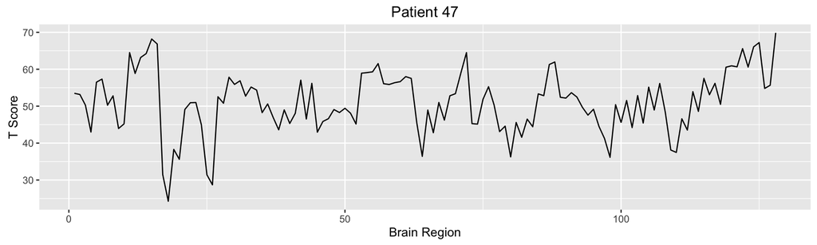

```r
baseline <- Depression[,125:252]
b <- as.numeric(baseline[47,])
x <- seq(1,128,1)
qplot(x,b,geom='line',xlab='Brain Region',ylab='T Score',main=paste('Patient 47'))
```

Side by side boxplots show almost no difference between responders and non-responders, which is bad.

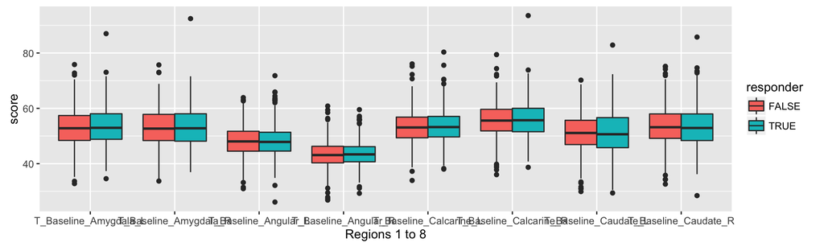

```r
stackregion <- function(regions, outcome) {
  n <- length(outcome)
  score <- rep(NA, n*8)
  name <- rep(NA, n*8)
  responder <- rep(NA, n*8)
  patient <- rep(NA, n*8)
  for (i in 1:8) {
    score[((i-1)*n+1):((i-1)*n+n)] <- as.numeric(regions[,i])
    name[((i-1)*n+1):((i-1)*n+n)] <- colnames(regions)[i]
    responder[((i-1)*n+1):((i-1)*n+n)] <- outcome
    patient[((i-1)*n+1):((i-1)*n+n)] <- seq(1, n, 1)
  }
  stacked <- data.frame(score,name,responder,patient)
  return(stacked)
}
outcome <- (Depression$Pre_BDI-Depression$POST_BDI)>0.5*Depression$Pre_BDI
i <- 1
regions <- stackregion(Depression[,(125+(i-1)*8):(132+(i-1)*8)],outcome)
ggplot(data=regions,aes(x=as.factor(name),y=score,fill=responder)) +
  geom_boxplot() + labs(x=paste('Regions',(i-1)*8+1,'to',(i-1)*8+8))
```

## Dimensionality reduction

Since there are 128 brain regions, it would be helpful to identify the important ones. The first two principal components account for most of the variance.

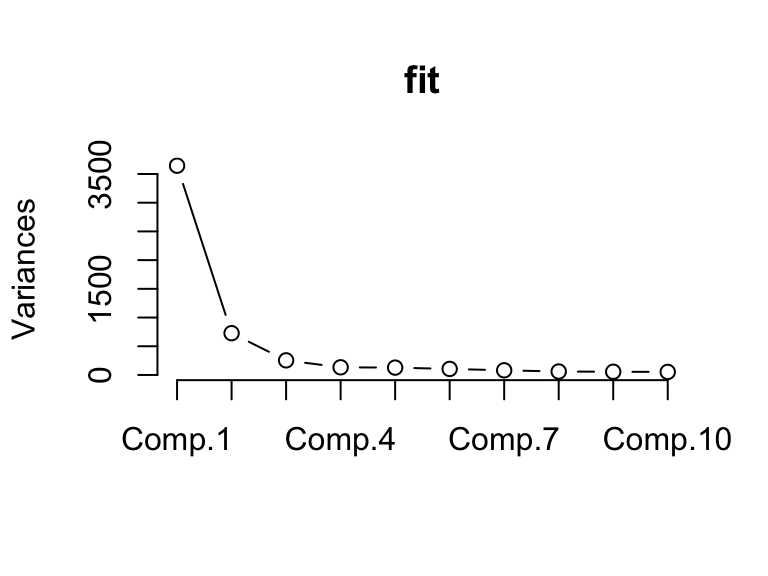

```r
fit <- princomp(baseline, cor=FALSE)
plot(fit,type="lines")
```

However, the data do not look separable, which is expected.

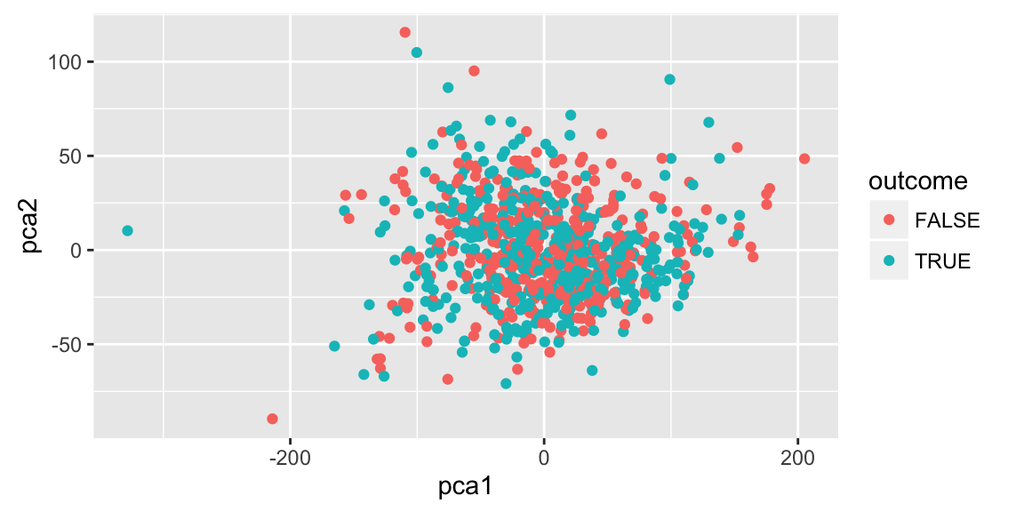

```r
pca1 <- fit$scores[,1]
pca2 <- fit$scores[,2]
pca <- data.frame(pca1, pca2, outcome)
ggplot(data=pca, aes(x=pca1, y=pca2, colour=outcome)) + geom_point()
```

Even the magical tSNE method can’t produce a reasonable embedding.

```r
library(tsne)
tsne_data <- tsne(baseline, k=2, max_iter=100, epoch=20)
```

```
## sigma summary: Min. : 0.3841 |1st Qu. : 0.4769 |Median : 0.5062 |Mean : 0.5233 |3rd Qu. : 0.5385 |Max. : 1.175 |
```

```
## Epoch: Iteration #20 error is: 21.0554865797264
```

```
## Epoch: Iteration #40 error is: 21.1742826375591
```

```
## Epoch: Iteration #60 error is: 21.1998349036394
```

```
## Epoch: Iteration #80 error is: 21.3640287070767
```

```
## Epoch: Iteration #100 error is: 21.2733948902414
```

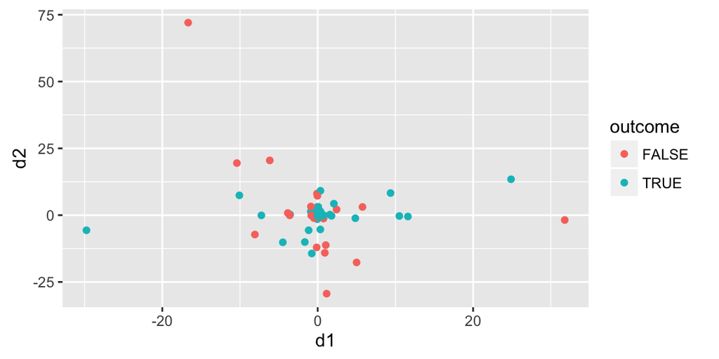

```r
embedding <- data.frame(d1=tsne_data[,1], d2=tsne_data[,2], outcome)
ggplot(data=embedding, aes(x=d1, y=d2, colour=outcome)) + geom_point()
```

## Classification models

We will go ahead to build classification models regardless. First, penalized logistic regression. Shrinkage does not improve prediction accuracy.

```r
library(glmnet)
```

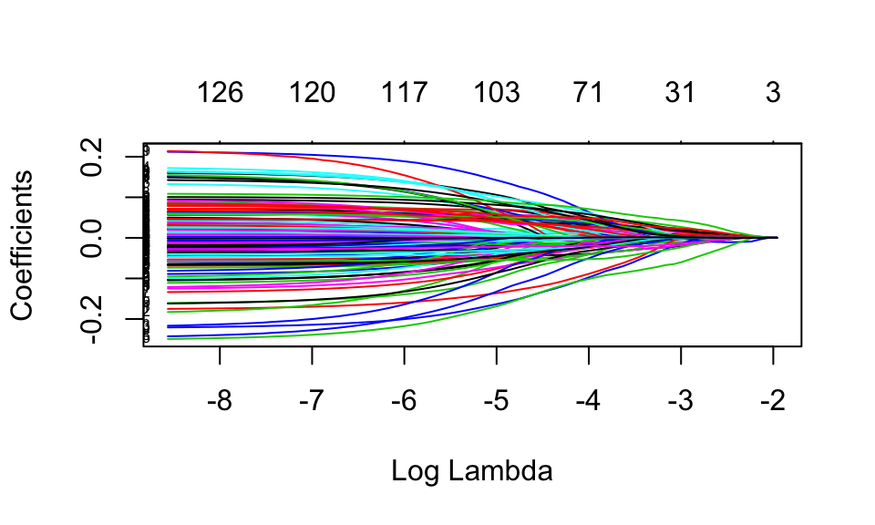

```r
X <- as.matrix(cbind(baseline, Pre_BDI=Depression$Pre_BDI))

indices <- sample(1:828,828)
Xtest <- X[indices[1:160],]
ytest <- outcome[indices[1:160]]
Xtrain <- X[indices[161:828],]
ytrain <- outcome[indices[161:828]]

fit <- glmnet(Xtrain, as.factor(ytrain), family='binomial', standardize=FALSE)
plot(fit, xvar ='lambda', label=TRUE)
```

```r
coef(fit, s=0.1)
```

```
## 130 x 1 sparse Matrix of class "dgCMatrix"
##                                             1
## (Intercept)                     -2.103671e-01
## T_Baseline_Amygdala_L            .
## T_Baseline_Amygdala_R            .
## T_Baseline_Angular_L             .
## T_Baseline_Angular_R             .
## T_Baseline_Calcarine_L           .
## T_Baseline_Calcarine_R           .
## T_Baseline_Caudate_L             .
## T_Baseline_Caudate_R             .
## T_Baseline_Cerebellum_10_L       .
## T_Baseline_Cerebellum_10_R       .
## T_Baseline_Cerebellum_3_L        .
## T_Baseline_Cerebellum_3_R        .
## T_Baseline_Cerebellum_4_5_L      .
## T_Baseline_Cerebellum_4_5_R      .
## T_Baseline_Cerebellum_6_L        .
## T_Baseline_Cerebellum_6_R        .
## T_Baseline_Cerebellum_7b_L       .
## T_Baseline_Cerebellum_7b_R       .
## T_Baseline_Cerebellum_8_L        .
## T_Baseline_Cerebellum_8_R        .
## T_Baseline_Cerebellum_9_L        1.775090e-03
## T_Baseline_Cerebellum_9_R        .
## T_Baseline_Cerebellum_Crus1_L    .
## T_Baseline_Cerebellum_Crus1_R    .
## T_Baseline_Cerebellum_Crus2_L   -4.835937e-04
## T_Baseline_Cerebellum_Crus2_R    .
## T_Baseline_Cingulum_Ant_L        .
## T_Baseline_Cingulum_Ant_R        .
## T_Baseline_Cingulum_Mid_L        .
## T_Baseline_Cingulum_Mid_R        .
## T_Baseline_Cingulum_Post_L       .
## T_Baseline_Cingulum_Post_R       .
## T_Baseline_Cuneus_L              .
## T_Baseline_Cuneus_R              .
## T_Baseline_Frontal_Inf_Oper_L    .
## T_Baseline_Frontal_Inf_Oper_R    .
## T_Baseline_Frontal_Inf_Orb_L     .
```

[output cut: 77 more lines]

```
## T_Baseline_Temporal_Sup_Mid_L    .
## T_Baseline_Temporal_Sup_Mid_R    .
## T_Baseline_Temporal_Sup_Post_L   .
## T_Baseline_Temporal_Sup_Post_R   .
## T_Baseline_Thalamus_L            .
## T_Baseline_Thalamus_R            .
## T_Baseline_Vermis_1_2            .
## T_Baseline_Vermis_10             .
## T_Baseline_Vermis_3              .
## T_Baseline_Vermis_4_5            .
## T_Baseline_Vermis_6              .
## T_Baseline_Vermis_7              .
## T_Baseline_Vermis_8              .
## T_Baseline_Vermis_9              .
## Pre_BDI                          .
```

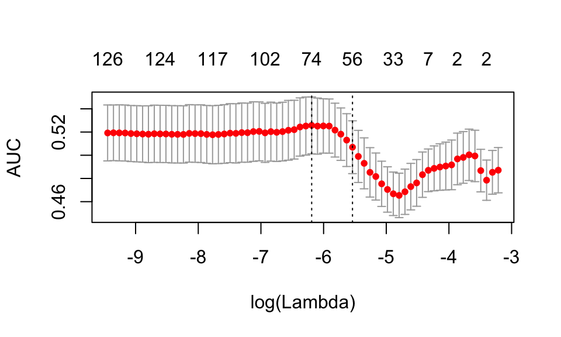

```r
cvfit = cv.glmnet(X, outcome, family='binomial', type.measure='auc')
plot(cvfit)
```

Then support vector machine and gradient boosted decision trees with 5-fold cross-validation. None of them does well.

```r
library(e1071)
library(xgboost)
dat <- cbind(outcome,baseline,Depression$Pre_BDI)
indices <- sample(1:828,800)
dat <- dat[indices,]
accuracy1 <- 0
accuracy2 <- 0
for (i in 1:5) {
  current <- seq(1+(i-1)*160,160+(i-1)*160,1)
  train <- dat[-current,]
  test <- dat[current,]
  fit1 <- svm(as.factor(outcome)~.,data=train)
  pred1 <- predict(fit1,test[,-1],type='class')
  accuracy1 <- accuracy1+sum(test$outcome==pred1)
  fit2 <- xgboost(data=as.matrix(train[,-1]),label=train$outcome,nrounds=10,max.depth=5,
                 objective='binary:logistic',verbose=0)
  pred2 <- predict(fit2, as.matrix(test[,-1]))
  accuracy2 <- accuracy2+sum(test$outcome==(pred2>0.5))
}
accuracy1/800
```

```
## [1] 0.49125
```

```r
accuracy2/800
```

```
## [1] 0.52375
```